# Variable Selection

## Feature Selection - Variable Selection (or variable selection) with GBM

So, what if you want to reduce you data’s high dimensionality but still need to preserve you variables?

PCA variables will not do the trick as they’re synthetic and made up of bits and pieces of other variables. A common solution to this conundrum is [variable selection](https://en.wikipedia.org/wiki/Feature_selection). This is the process of taking a sample of your wide data set and attempt to find the most valuable ones.

We will work with caret and use its function **varImp** (variable importance).

We’re going to use two models: [gbm (Generalized Boosted Models)](https://en.wikipedia.org/wiki/Gradient_boosting), a tree-based classifier and a regression [glmnet (Generalized Linear Models)](https://en.wikipedia.org/wiki/Generalized_linear_model). Approaching a new data set using different models is one way of getting a handle on your data. **gbm uses boosted trees while glmnet uses regression. (Note: gbm can handle NAs but glmnet cannot)**.

Using 2 different models to see if they return the same important variables. If they provide different models, then an ensembling method to get a more powerful prediction model.

### Get Data - Again

Using the same data from the highDimensionalData.Rmd (https://archive.ics.uci.edu/ml/datasets/Gisette).

```r
gisetteRaw <- read.table("./data/gisette_train.txt", sep = '', header = FALSE, stringsAsFactors = FALSE)
g_labels <- read.table("./data/gisette_train.labels", sep = '', header = FALSE, stringsAsFactors = FALSE)

# build data set - some models want numeric rather than integers so we just to it automatically as a best practice
gisette_df <- cbind(as.data.frame(sapply(gisetteRaw, as.numeric)), cluster=g_labels$V1)
rm(gisetteRaw, g_labels)
```

We need to split the data into three sets, one for training, one for testing and another for validating. Validation is used for scoring.

```r
set.seed(1234)
split <- sample(nrow(gisette_df), floor(0.5*nrow(gisette_df)))#50/50 split train and validate
gisette_df_train_test <- gisette_df[split,]
gisette_df_validate <- gisette_df[-split,]
# split AGAIN gisette_df_train_test data set into training and testing
set.seed(1234)
split <- sample(nrow(gisette_df_train_test), floor(0.5*nrow(gisette_df_train_test)))
traindf <- gisette_df_train_test[split,]
testdf <- gisette_df_train_test[-split,]
rm(gisette_df, split)
```

### GBM

#### No Variable Selection

Let’s start with a GBM model. We will use the trainControl function from caret. This function will cross-validate our data in order to find the best parameters for the GBM model. Warning: this takes a while. . . .

```r
# caret requires a factor of non-numeric value
traindf$cluster <- ifelse(traindf$cluster == 1, "yes", "no")#required to be a factor
traindf$cluster <- as.factor(traindf$cluster )
fitControl <- trainControl(method='cv', number=3, returnResamp='none', verboseIter= FALSE,
            summaryFunction = twoClassSummary, classProbs = TRUE)#note classProbs to get probabilities for the label factor
#gbm_model1 <- train(cluster~., data=traindf, trControl=fitControl, method="gbm", metric='roc')
```

```r
#saveRDS(gbm_model1, "gbm_model1.rds")
```

```r
print(gbm_model1)
```

```
## Stochastic Gradient Boosting
##
## 1500 samples
## 5000 predictors
##    2 classes: 'no', 'yes'
##
## No pre-processing
## Resampling: Cross-Validated (3 fold)
## Summary of sample sizes: 1001, 1000, 999
## Resampling results across tuning parameters:
##
##   interaction.depth  n.trees  ROC        Sens       Spec
##   1                   50      0.9651623  0.8708352  0.9287696
##   1                  100      0.9803887  0.9093233  0.9417197
##   1                  150      0.9836264  0.9285674  0.9468927
##   2                   50      0.9813791  0.9161820  0.9455957
##   2                  100      0.9873977  0.9423075  0.9533727
##   2                  150      0.9885227  0.9450453  0.9520757
##   3                   50      0.9862671  0.9533098  0.9443087
##   3                  100      0.9888476  0.9615459  0.9572588
##   3                  150      0.9893895  0.9560476  0.9546647
##
## Tuning parameter 'shrinkage' was held constant at a value of 0.1
##
## Tuning parameter 'n.minobsinnode' was held constant at a value of 10
## ROC was used to select the optimal model using  the largest value.
## The final values used for the model were n.trees = 150,
##  interaction.depth = 3, shrinkage = 0.1 and n.minobsinnode = 10.
```

By printing `gbm_model`, you get the best settings at the bottom of the report:

Tuning parameter `shrinkage` was held constant at a value of 0.1 ROC was used to select the optimal model using the largest value. The final values used for the model were `n.trees` = 150, `interaction.depth` = 3 and `shrinkage = 0.1`. We will use these values going forward - *this saves lots of time since we do not need to cross validate*.

```r
testdf$cluster <- ifelse(testdf$cluster == 1, "yes", "no")
testdf$cluster <- as.factor(testdf$cluster)
predictions <- predict(object = gbm_model1, testdf[,setdiff(names(testdf),
              'cluster')], type='raw')#remove the cluster label; raw provides 1 or -1
head(predictions)
```

```
## [1] yes yes no  yes yes no
## Levels: no yes
```

```r
print(postResample(pred=predictions, obs=testdf$cluster))
```

```
##  Accuracy     Kappa
## 0.9586667 0.9172863
```

```r
#DO NOT summary(gbm_model) - with 5000 variables, it will bomb!
```

#### With Variable Selection

This is where the varImp function comes in handy. Lets plot only the top 50 best variables:

```r
head(varImp(gbm_model1, scale=FALSE))#I think this will work
```

[output not shown]

[output cut: 4953 more lines]

```
## V4992   0.00000000
## V4993   0.00000000
## V4994   0.00000000
## V4995   0.27491660
## V4996   0.00000000
## V4997   0.00000000
## V4998   0.00000000
## V4999   0.00000000
## V5000   0.00000000
##
## $model
## [1] "gbm"
##
## $calledFrom
## [1] "varImp"
```

```r
tail(varImp(gbm_model1, scale=FALSE))
```

[output not shown]

[output cut: 4953 more lines]

```
## V4992   0.00000000
## V4993   0.00000000
## V4994   0.00000000
## V4995   0.27491660
## V4996   0.00000000
## V4997   0.00000000
## V4998   0.00000000
## V4999   0.00000000
## V5000   0.00000000
##
## $model
## [1] "gbm"
##
## $calledFrom
## [1] "varImp"
```

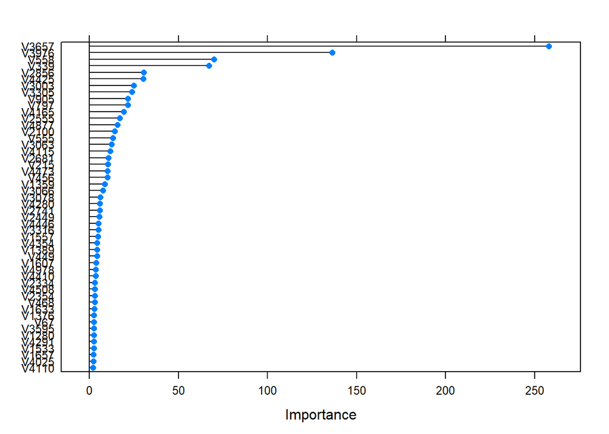

```r
# only plot top 20 variables
plot(varImp(gbm_model1, scale=F), top = 50)
```

Here you see that V3657 is the most predictive feature for the outcome ‘cluster’. No, with a little handy work, we can do a much better job at presenting the information:

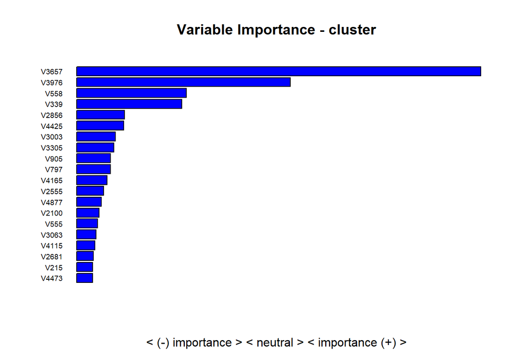

```r
# display variable importance on a +/- scale
vimp <- varImp(gbm_model1, scale=F)
results <- data.frame(row.names(vimp$importance),vimp$importance$Overall)
results$VariableName <- rownames(vimp)
colnames(results) <- c('VariableName','Weight')
results <- results[order(results$Weight),]
# we do not want factors, just characters
results$VariableName <- as.character(results$VariableName)
# let's display the best 20 features
results_temp <- tail(results,20)
par(mar=c(5,5,4,2)) # increase y-axis margin.
{xx <- barplot(results_temp$Weight, width = 0.85, main = paste("Variable Importance -",'cluster'), horiz = T,
              xlab = "< (-) importance > < neutral > < importance (+) >", axes =FALSE,
              col = ifelse((results_temp$Weight > 0), 'blue', 'red'))
axis(2, at=xx, labels=results_temp$VariableName, tick=FALSE, las=2, line=-0.3, cex.axis=0.6)}
```

Now comes the fun part, let’s run the GBM model different quantities of top variables and score it with our validation set.

```r
head(results)
```

```
##   VariableName Weight
## 1           V1      0
## 2           V2      0
## 3           V3      0
## 4           V4      0
## 5           V5      0
## 6           V6      0
```

```r
tail(results)
```

```
##      VariableName    Weight
## 4425        V4425  30.07970
## 2856        V2856  30.47645
## 339          V339  67.09762
## 558          V558  69.91811
## 3976        V3976 136.35734
## 3657        V3657 257.89353
```

```r
traindf_truncated <- traindf[, c(tail(results$VariableName,2), 'cluster')]#Get two most powerful variables
# caret requires a factor of non-numeric value

# we don't need parameters as we already know the best ones from previous trainControlcall
fitControl <- trainControl(method="none")

gbm_model <- train(cluster~., data=traindf_truncated, tuneGrid = expand.grid(n.trees = 150,
            interaction.depth = 3, shrinkage = 0.1, n.minobsinnode=10),
            trControl=fitControl, method="gbm", metric='roc')
predictions <- predict(object=gbm_model, gisette_df_validate[,setdiff(names(traindf_truncated),
          'cluster')], type='raw')
head(predictions)
```

```
## [1] yes yes yes yes no  no
## Levels: no yes
```

```r
# caret requires a factor of non-numeric value; using the validation set
gisette_df_validate$cluster <- ifelse(gisette_df_validate$cluster == 1, "yes", "no")
gisette_df_validate$cluster <- as.factor(gisette_df_validate$cluster)
print(postResample(pred=predictions, obs=gisette_df_validate$cluster))
```

```
##  Accuracy     Kappa
## 0.8343333 0.6690747
```

Lets try larger amounts of the top variables and measure accuracy on the validation set. We’ll try anything with a weight larger than 10 (turns out to be 20 variables):

```r
head(results)
```

```
##   VariableName Weight
## 1           V1      0
## 2           V2      0
## 3           V3      0
## 4           V4      0
## 5           V5      0
## 6           V6      0
```

```r
tail(results)
```

```
##      VariableName    Weight
## 4425        V4425  30.07970
## 2856        V2856  30.47645
## 339          V339  67.09762
## 558          V558  69.91811
## 3976        V3976 136.35734
## 3657        V3657 257.89353
```

```r
# Let's start by modeling with different results$Weight values
traindf_truncated <- traindf[, c(results$VariableName[results$Weight > 10], 'cluster')]

fitControl <- trainControl(method="none")
gbm_model <- train(cluster~., data=traindf_truncated,
         tuneGrid = expand.grid(n.trees = 150, interaction.depth = 3,
         shrinkage = 0.1, n.minobsinnode=10), trControl=fitControl, method="gbm", metric='roc')
predictions <- predict(object=gbm_model, gisette_df_validate[,setdiff(names(traindf_truncated),
               'cluster')], type='raw')
print(postResample(pred=predictions, obs=as.factor(gisette_df_validate$cluster)))
```

```
##  Accuracy     Kappa
## 0.9336667 0.8672728
```

```r
traindf_truncated <- traindf[, c(results$VariableName[results$Weight > 2], 'cluster')]
fitControl <- trainControl(method="none")
gbm_model <- train(cluster~., data=traindf_truncated,
         tuneGrid = expand.grid(n.trees = 150, interaction.depth = 3,
         shrinkage = 0.1, n.minobsinnode=10),
         trControl=fitControl, method="gbm", metric='roc')
predictions <- predict(object=gbm_model, gisette_df_validate[,setdiff(names(traindf_truncated),
               'cluster')], type='raw')
print(postResample(pred=predictions, obs=as.factor(gisette_df_validate$cluster)))
```

```
##  Accuracy     Kappa
## 0.9513333 0.9026009
```

## Feature Selection - Variable Selection with GLMNET

Above we worked with GBM, now we will repeat with GLMNET (Regression Model)

### Get Data - Again

(https://archive.ics.uci.edu/ml/datasets/Gisette).

```r
rm(list=ls())
gisetteRaw <- read.table("./data/gisette_train.txt", sep = '', header = FALSE, stringsAsFactors = FALSE)
g_labels <- read.table("./data/gisette_train.labels", sep = '', header = FALSE, stringsAsFactors = FALSE)
# build data set
gisette_df <- cbind(as.data.frame(sapply(gisetteRaw, as.numeric)), cluster=g_labels$V1)
set.seed(1234)
split <- sample(nrow(gisette_df), floor(0.5*nrow(gisette_df)))
gisette_df_train_test <- gisette_df[split,]
gisette_df_validate <- gisette_df[-split,]
# split gisette_df_train_test data set into training and testing
set.seed(1234)
split <- sample(nrow(gisette_df_train_test), floor(0.5*nrow(gisette_df_train_test)))
traindf <- gisette_df_train_test[split,]
testdf <- gisette_df_train_test[-split,]
rm(gisetteRaw, g_labels)
```

### GLMNET

#### Full Dataset

Lets change gears with a regression-based model - GLMNET - but still in the caret library as this will allow us to re-use most of our previous code (think about that - you have over 150 models supported in caret - type names(getModelInfo()) to see the full list of supported models). Let’s generalize our outcome name and predictor names going forward. This is a good habit and will make code re-use much easier. This is a big file so it is slow and may return a warning stating that maxit should be larger - we can ignore that here as its beyond the scope of this exercise.

```r
outcome_name <- 'cluster'
predictors_names <- setdiff(names(traindf), outcome_name)
# caret requires a factor of non-numeric value
traindf$cluster <- ifelse(traindf$cluster == 1, "yes", "no")
traindf$cluster <- as.factor(traindf$cluster )
fitControl <- trainControl(method='cv', number=3, returnResamp='none',
            summaryFunction = twoClassSummary, classProbs = TRUE)
#glmnet_model <- train(x=traindf[, predictors_names], y = traindf[, outcome_name],
#                 method = "glmnet", metric = "roc", trControl = fitControl)
```

```r
saveRDS(glmnet_model, "glmnet_model.rds")
```

```r
glmnet_model <- readRDS("glmnet_model.rds")
```

Print the glmnet_model object to get the best parameters.

```r
print(glmnet_model)
```

```
## glmnet
##
## 1500 samples
## 5000 predictors
##    2 classes: 'no', 'yes'
##
## No pre-processing
## Resampling: Cross-Validated (3 fold)
## Summary of sample sizes: 1001, 1000, 999
## Resampling results across tuning parameters:
##
##   alpha  ROC        Sens       Spec
##   0.10   0.9870704  0.9368318  0.9572487
##   0.55   0.9343627  0.8090558  0.9067455
##   1.00   0.8827623  0.8090728  0.8653013
##
## Tuning parameter 'lambda' was held constant at a value of 0.2136412
## ROC was used to select the optimal model using  the largest value.
## The final values used for the model were alpha = 0.1 and lambda
##  = 0.2136412.
```

The final values used for the model were alpha = 0.1 and lambda = 0.2136412. We run the base predictions on the full data set:

```r
# caret requires a factor of non-numeric value
testdf$cluster <- ifelse(testdf$cluster == 1, "yes", "no")
testdf$cluster <- as.factor(testdf$cluster )
predictions <- predict(object=glmnet_model, testdf[,setdiff(names(testdf), 'cluster')], type='raw')
head(predictions)
```

```
## [1] yes yes no  yes yes no
## Levels: no yes
```

```r
print(postResample(pred=predictions, obs=as.factor(testdf$cluster)))
```

```
##  Accuracy     Kappa
## 0.9486667 0.8972135
```

Accuracy is 94.86%

#### Variable Selection Dataset

```r
head(varImp(glmnet_model,scale=F)$importance,100)
```

```
##           Overall
## V1   0.000000e+00
## V2   0.000000e+00
## V3   0.000000e+00
## V4   0.000000e+00
## V5   0.000000e+00
## V6   0.000000e+00
## V7   0.000000e+00
## V8   0.000000e+00
## V9   0.000000e+00
## V10  0.000000e+00
## V11  0.000000e+00
## V12  0.000000e+00
## V13  0.000000e+00
## V14  0.000000e+00
## V15  3.591286e-06
## V16  0.000000e+00
## V17  0.000000e+00
## V18  0.000000e+00
## V19  0.000000e+00
## V20  0.000000e+00
## V21  0.000000e+00
## V22  0.000000e+00
## V23  0.000000e+00
## V24  0.000000e+00
## V25  0.000000e+00
## V26  0.000000e+00
## V27  0.000000e+00
## V28  0.000000e+00
## V29  0.000000e+00
## V30  0.000000e+00
## V31  0.000000e+00
## V32  0.000000e+00
## V33  0.000000e+00
## V34  0.000000e+00
## V35  0.000000e+00
## V36  0.000000e+00
## V37  0.000000e+00
## V38  0.000000e+00
## V39  0.000000e+00
```

[output cut: 46 more lines]

```
## V86  0.000000e+00
## V87  0.000000e+00
## V88  0.000000e+00
## V89  0.000000e+00
## V90  0.000000e+00
## V91  0.000000e+00
## V92  0.000000e+00
## V93  0.000000e+00
## V94  0.000000e+00
## V95  0.000000e+00
## V96  0.000000e+00
## V97  0.000000e+00
## V98  0.000000e+00
## V99  0.000000e+00
## V100 0.000000e+00
```

Let’s see if we can plot this by removing intermediary values:

[figure not shown]

```r
# display variable importance on a +/- scale
vimp <- varImp(glmnet_model, scale=F)
results <- data.frame(row.names(vimp$importance),vimp$importance$Overall)
results$VariableName <- rownames(vimp)
colnames(results) <- c('VariableName','Weight')
results <- results[order(results$Weight),]
# we do not want factors, just characters
results$VariableName <- as.character(results$VariableName)
par(mar=c(5,5,4,2)) # increase y-axis margin.
xx <- barplot(results$Weight, width = 0.85, main = paste("Variable Importance -",'cluster'), horiz = T,
              xlab = "< (-) importance > < neutral > < importance (+) >", axes = FALSE,
              col = ifelse((results$Weight > 0), 'blue', 'red'))
axis(2, at=xx, labels=results$VariableName, tick=FALSE, las=2, line=-0.3, cex.axis=0.6)
```

Still not ideal, let’s remove more of the middle variables. Let’s use the handy subset

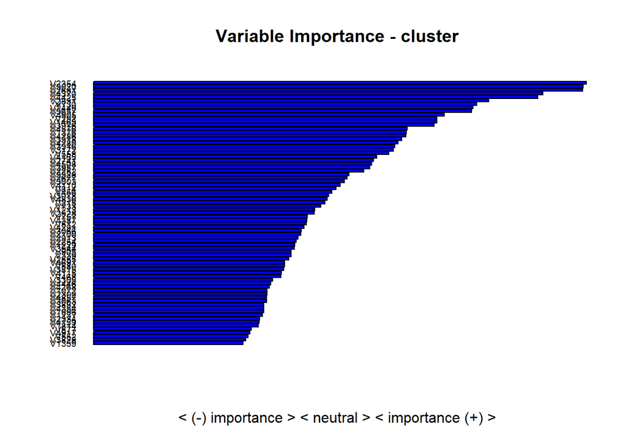

```r
# display variable importance on a +/- scale
vimp <- varImp(glmnet_model, scale=F)
results <- data.frame(row.names(vimp$importance),vimp$importance$Overall)
results$VariableName <- rownames(vimp)
colnames(results) <- c('VariableName','Weight')
results <- results[order(results$Weight),]
# remove all zero variables - non-predictive
results <- subset(results, results$Weight > 0.0001 | results$Weight < -0.0001 )
# we do not want factors, just characters
results$VariableName <- as.character(results$VariableName)
par(mar=c(5,5,4,2)) # increase y-axis margin.
xx <- barplot(results$Weight, width = 0.85, main = paste("Variable Importance -",'cluster'), horiz = T,
              xlab = "< (-) importance > < neutral > < importance (+) >", axes = FALSE,
              col = ifelse((results$Weight > 0), 'blue', 'red'))
axis(2, at=xx, labels=results$VariableName, tick=FALSE, las=2, line=-0.3, cex.axis=0.6)
```

```r
traindf_truncated <- traindf[, c(results$VariableName, 'cluster')]
dim(traindf_truncated)
```

```
## [1] 1500   76
```

```r
fitControl <- trainControl(method="none")
predictors_names <- setdiff(names(traindf_truncated), 'cluster')
glmnet_model <- train(traindf_truncated[,predictors_names], traindf[,outcome_name], method='glmnet',
            metric='roc', trControl=fitControl, tuneGrid = expand.grid(alpha=0.1, lambda=0.1))

predictions <- predict(object=glmnet_model, gisette_df_validate[,setdiff(names(traindf_truncated),
             'cluster')], type='raw')
# caret requires a factor of non-numeric value
gisette_df_validate$cluster <- ifelse(gisette_df_validate$cluster == 1, "yes", "no")
gisette_df_validate$cluster <- as.factor(gisette_df_validate$cluster )
print(postResample(pred=predictions, obs=gisette_df_validate$cluster))
```

```
##  Accuracy     Kappa
## 0.9500000 0.8999966
```